# Presidential Election: Bayesian Inference

Brandon Owens

2024-03-01

## Import Necessary Libraries

```r
library(dplyr)
```

```r
library(nflfastR)
library(ggplot2)
```

## Import Polling Data and Cleaning

```r
polls <- read.csv("csvs/presidential_polls.csv")

total_sum = sum(polls$rawpoll_trump) + sum(polls$rawpoll_clinton)


polls$norm_trump <- (polls$rawpoll_trump / total_sum) * 10000
polls$norm_clinton <- (polls$rawpoll_clinton / total_sum) * 10000

polls$state <-as.factor(polls$state)
```

Imported polling data. Normalized all raw scores for only Trump and Clinton. This analysis will ignore the other candidates! Also changed the states to factors so that I can group them later.

```r
levels(polls$state)
```

```
##  [1] "Alabama"              "Alaska"               "Arizona"
##  [4] "Arkansas"             "California"           "Colorado"
##  [7] "Connecticut"          "Delaware"             "District of Columbia"
## [10] "Florida"              "Georgia"              "Hawaii"
## [13] "Idaho"                "Illinois"             "Indiana"
## [16] "Iowa"                 "Kansas"               "Kentucky"
## [19] "Louisiana"            "Maine"                "Maine CD-1"
## [22] "Maine CD-2"           "Maryland"             "Massachusetts"
## [25] "Michigan"             "Minnesota"            "Mississippi"
## [28] "Missouri"             "Montana"              "Nebraska"
## [31] "Nebraska CD-1"        "Nebraska CD-2"        "Nebraska CD-3"
## [34] "Nevada"               "New Hampshire"        "New Jersey"
## [37] "New Mexico"           "New York"             "North Carolina"
## [40] "North Dakota"         "Ohio"                 "Oklahoma"
## [43] "Oregon"               "Pennsylvania"         "Rhode Island"
## [46] "South Carolina"       "South Dakota"         "Tennessee"
## [49] "Texas"                "U.S."                 "Utah"
## [52] "Vermont"              "Virginia"             "Washington"
## [55] "West Virginia"        "Wisconsin"            "Wyoming"
```

Some states have multiple sub polls as seen by the levels of the factor. I just want all of the subpolls to be identified as belonging to that state.

```r
polls$state <- gsub("Nebraska CD-1|Nebraska CD-2|Nebraska CD-3", "Nebraska", polls$state)
polls$state <- gsub("Maine CD-1|Maine CD-2", "Maine", polls$state)
polls$state <-as.factor(polls$state)
levels(polls$state)
```

```
##  [1] "Alabama"              "Alaska"               "Arizona"
##  [4] "Arkansas"             "California"           "Colorado"
##  [7] "Connecticut"          "Delaware"             "District of Columbia"
## [10] "Florida"              "Georgia"              "Hawaii"
## [13] "Idaho"                "Illinois"             "Indiana"
## [16] "Iowa"                 "Kansas"               "Kentucky"
## [19] "Louisiana"            "Maine"                "Maryland"
## [22] "Massachusetts"        "Michigan"             "Minnesota"
## [25] "Mississippi"          "Missouri"             "Montana"
## [28] "Nebraska"             "Nevada"               "New Hampshire"
## [31] "New Jersey"           "New Mexico"           "New York"
## [34] "North Carolina"       "North Dakota"         "Ohio"
## [37] "Oklahoma"             "Oregon"               "Pennsylvania"
## [40] "Rhode Island"         "South Carolina"       "South Dakota"
## [43] "Tennessee"            "Texas"                "U.S."
## [46] "Utah"                 "Vermont"              "Virginia"
## [49] "Washington"           "West Virginia"        "Wisconsin"
## [52] "Wyoming"
```

```r
polls <- polls[polls$grade == c("A", "A-", "A+", "B", "B+", "B-"), ]
```

Here, I made the sub polls in Nebraska and Maine associated with the state and removed all polling that didn’t at least have a “B-” grade.

## Grabbing Sample Means and Variances for Both Candidates

```r
state_grouping <- polls  %>%
  group_by(state) %>%
  summarize(state = state,
            trump_mean = mean(norm_trump, na.rm = TRUE),
            clinton_mean = mean(norm_clinton, na.rm = TRUE),
            trump_var = var(norm_trump, na.rm = TRUE),
            clinton_var = var(norm_clinton, na.rm = TRUE)) %>%
  distinct(state, .keep_all = TRUE)

state_grouping
```

```
## # A tibble: 52 × 5
## # Groups:   state [52]
##    state                trump_mean clinton_mean trump_var clinton_var
##    <fct>                     <dbl>        <dbl>     <dbl>       <dbl>
##  1 Alabama                   0.651        0.336  0.000899    0.0137
##  2 Alaska                    0.430        0.379  0.00487     0.00488
##  3 Arizona                   0.480        0.477  0.00619     0.00110
##  4 Arkansas                  0.532        0.400  0.00678     0.00365
##  5 California                0.339        0.679  0.00259     0.00772
##  6 Colorado                  0.428        0.493  0.00795     0.000815
##  7 Connecticut               0.393        0.553  0.00341     0.00341
##  8 Delaware                  0.386        0.486  0.00239     0.00400
##  9 District of Columbia      0.249        0.645  0.00681     0.0133
## 10 Florida                   0.507        0.508  0.00141     0.00359
## # ℹ 42 more rows
```

Utilizing the state grouping, I grab each candidates sample mean and sample variance that will be later used in the posteriors for each individual state.

## Setting Up Priors

```r
states <- c(levels(state_grouping$state))
regions <- c("farwest", "rockies", "southwest", "southeast", "plains", "gl", "mideast", "ne")

farwest <- c("Washington", "Oregon", "Nevada", "California", "Alaska", "Hawaii")
rockies <- c("Montana", "Idaho", "Wyoming", "Utah", "Colorado")
southwest <- c("Arizona", "New Mexico", "Texas", "Oklahoma")
southeast <- c("Arkansas", "Louisiana", "Mississippi", "Alabama", "Georgia", "South Carolina", "North Carolina", "Florida", "Tennessee", "Kentucky", "West Virginia", "Virginia")
plains <- c("North Dakota", "South Dakota", "Nebraska", "Kansas", "Missouri", "Iowa", "Minnesota")
gl <- c("Wisconsin", "Michigan", "Illinois", "Indiana", "Ohio")
mideast <- c("District of Columbia", "Pennsylvania", "New York", "New Jersey", "Delaware", "Maryland")
ne <- c("Vermont", "New Hampshire", "Connecticut", "Rhode Island", "Massachusetts", "Maine")
```

I would like the prior distributions to be based off of surrounding geography for each state. Here we break up the U.S. into respective regions based on geographical areas.

```r
priors <- data.frame(column1=character(),
                            column2=character(),
                            column3=numeric(),
                            column4=numeric(),
                            column5=numeric(),
                            column6=numeric())

for (region in regions){
  region_states <- get(region)

  for (sel_state in region_states){
    polls_region = polls[polls$state %in% region_states, ]

    regional_states_polls = polls_region[polls_region$state != sel_state, ]
    trump_prior_var = var(regional_states_polls$norm_trump)
    clinton_prior_var = var(regional_states_polls$norm_trump)

    regional_states_df = state_grouping[state_grouping$state %in% region_states, ]
    regional_states_df$region <- region


    tmp_state_df <- regional_states_df[regional_states_df$state != sel_state, ] %>%
      group_by(region) %>%
      summarise(state = sel_state,
        trump_prior_mean = mean(trump_mean),
        clinton_prior_mean = mean(clinton_mean),
        trump_prior_var = trump_prior_var,
        clinton_prior_var = clinton_prior_var)

    priors <- rbind(priors, tmp_state_df)
  }
}
```

Creating a data frame that includes the prior means and variances for each candidate for each state. The priors are based on the means and variances for all surrounding states in the region excluding the state we are obtaining the parameters for.

```r
prior = priors[priors$state != "U.S.",]
state_grouping = state_grouping[state_grouping$state != "U.S.",]
```

We are going to ignore the national polls

```r
prior
```

```
## # A tibble: 51 × 6
##    region  state      trump_prior_mean clinton_prior_mean trump_prior_var
##    <chr>   <chr>                 <dbl>              <dbl>           <dbl>
##  1 farwest Washington            0.389              0.532         0.00579
##  2 farwest Oregon                0.382              0.530         0.00604
##  3 farwest Nevada                0.364              0.544         0.00422
##  4 farwest California            0.389              0.503         0.00598
##  5 farwest Alaska                0.371              0.563         0.00562
##  6 farwest Hawaii                0.389              0.520         0.00593
##  7 rockies Montana               0.491              0.358         0.0168
##  8 rockies Idaho                 0.473              0.381         0.0141
##  9 rockies Wyoming               0.485              0.394         0.0167
## 10 rockies Utah                  0.528              0.384         0.0145
## # ℹ 41 more rows
## # ℹ 1 more variable: clinton_prior_var <dbl>
```

```r
state_grouping
```

```
## # A tibble: 51 × 5
## # Groups:   state [51]
##    state                trump_mean clinton_mean trump_var clinton_var
##    <fct>                     <dbl>        <dbl>     <dbl>       <dbl>
##  1 Alabama                   0.651        0.336  0.000899    0.0137
##  2 Alaska                    0.430        0.379  0.00487     0.00488
##  3 Arizona                   0.480        0.477  0.00619     0.00110
##  4 Arkansas                  0.532        0.400  0.00678     0.00365
##  5 California                0.339        0.679  0.00259     0.00772
##  6 Colorado                  0.428        0.493  0.00795     0.000815
##  7 Connecticut               0.393        0.553  0.00341     0.00341
##  8 Delaware                  0.386        0.486  0.00239     0.00400
##  9 District of Columbia      0.249        0.645  0.00681     0.0133
## 10 Florida                   0.507        0.508  0.00141     0.00359
## # ℹ 41 more rows
```

Obtain a quick view of the data frames

```r
states <- states[states != "U.S."]
state_counts<- table(polls$state)
result_df <- data.frame(state = character(),
                        post_mean_trump = numeric(),
                        post_var_trump = numeric(),
                        post_mean_clinton = numeric(),
                        post_var_clinton = numeric())

for (state in states){
  n_count <- as.numeric(state_counts[state])

  trump_sample_mean <- state_grouping[state_grouping$state == state, ]$trump_mean
  trump_sample_var <- state_grouping[state_grouping$state == state, ]$trump_var
  clinton_sample_mean <- state_grouping[state_grouping$state == state, ]$clinton_mean
  clinton_sample_var <- state_grouping[state_grouping$state == state, ]$clinton_var
  trump_prior_mean <- prior[prior$state == state, ]$trump_prior_mean
  trump_prior_var <- prior[prior$state == state, ]$trump_prior_var
  clinton_prior_mean <- prior[prior$state == state, ]$clinton_prior_mean
  clinton_prior_mean <- prior[prior$state == state, ]$clinton_prior_var



  post_mean_trump <- ((((1/trump_prior_var)*trump_prior_mean) + ((n_count/trump_sample_var)*trump_sample_mean))) / (((1/trump_prior_var) + (n_count/trump_sample_var)))

  post_var_trump <- 1/((1/trump_prior_var) + (n_count/trump_sample_var))

  post_mean_clinton <- ((((1/clinton_prior_var)*clinton_prior_mean) + ((n_count/clinton_sample_var)*clinton_sample_mean))) / (((1/clinton_prior_var) + (n_count/clinton_sample_var)))

  post_var_clinton <- 1/((1/clinton_prior_var) + (n_count/clinton_sample_var))

  temp_df <- data.frame(state = state,
                        post_mean_trump = post_mean_trump,
                        post_var_trump = post_var_trump,
                        post_mean_clinton = post_mean_clinton,
                        post_var_clinton = post_var_clinton)
  result_df <- rbind(result_df, temp_df)
}
```

Determine posterior means and variances for each candidate for each state using conjugate normal poseterior.

```r
result_df
```

```
##                   state post_mean_trump post_var_trump post_mean_clinton
## 1               Alabama       0.6498615   6.349037e-05         0.3095904
## 2                Alaska       0.4249097   4.936611e-04         0.3613671
## 3               Arizona       0.4809303   2.413862e-04         0.4753887
## 4              Arkansas       0.5331274   3.557056e-04         0.3933189
## 5            California       0.3404746   1.332704e-04         0.6556631
## 6              Colorado       0.4319454   7.611579e-04         0.4893523
## 7           Connecticut       0.3918588   3.013976e-04         0.5383323
## 8              Delaware       0.3855416   1.793158e-04         0.4729031
## 9  District of Columbia       0.2696519   6.487468e-04         0.5703634
## 10              Florida       0.5075304   3.342552e-05         0.5041973
## 11              Georgia       0.5419244   4.414399e-05         0.4685349
## 12               Hawaii       0.3407869   2.885406e-04         0.5705453
## 13                Idaho       0.5861327   1.676744e-03         0.3278399
## 14             Illinois       0.4031265   2.257248e-04         0.5145959
```

[output cut: 89 more lines]

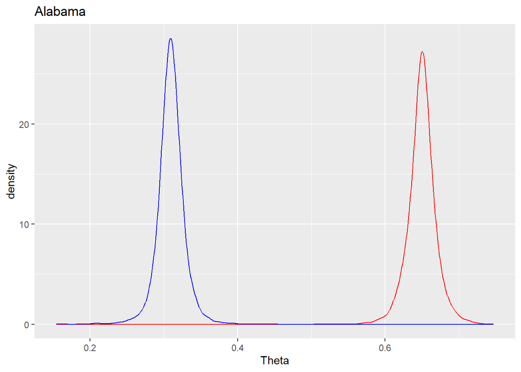

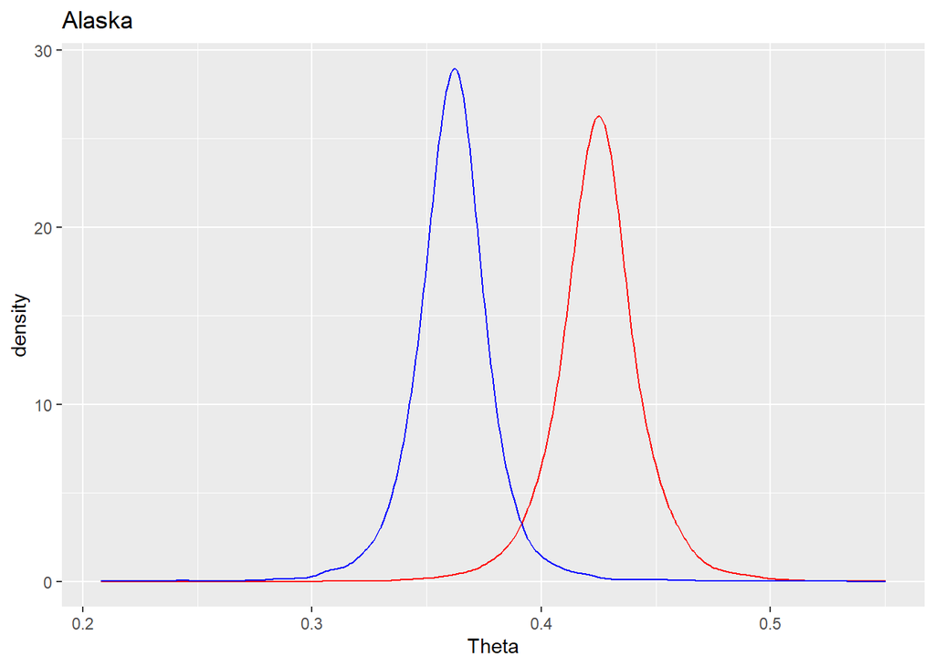

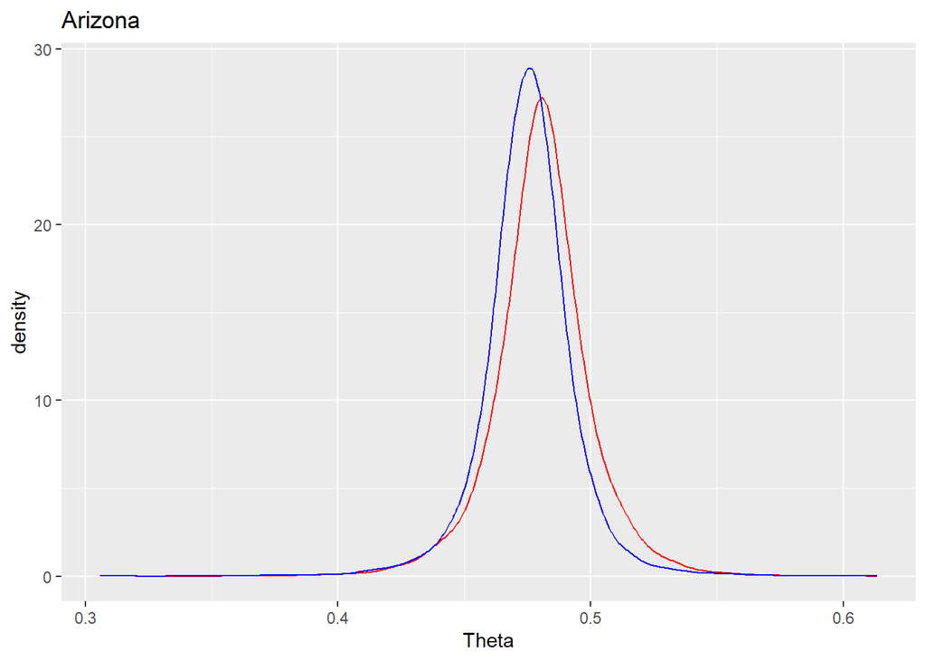

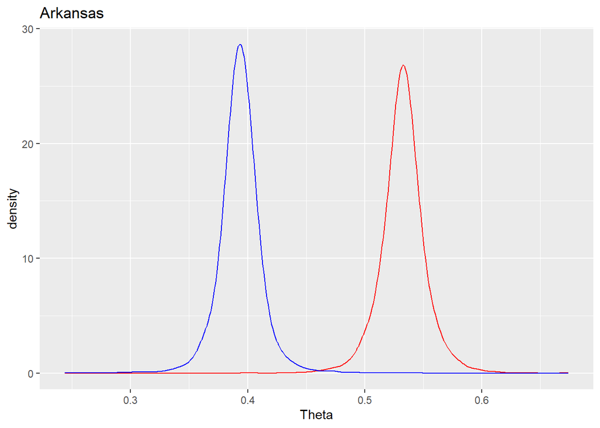

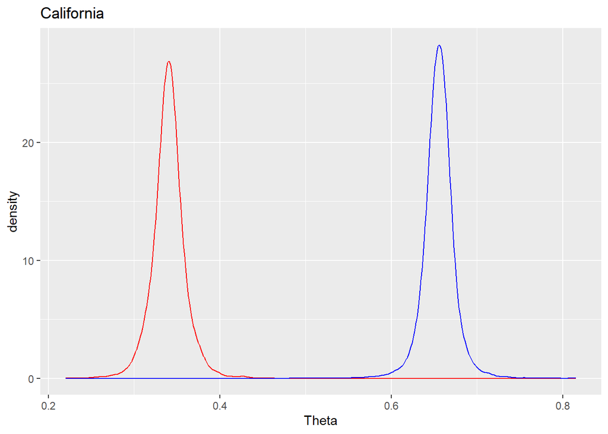

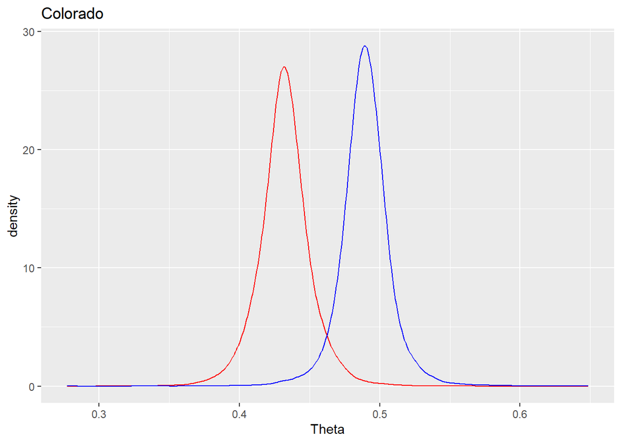

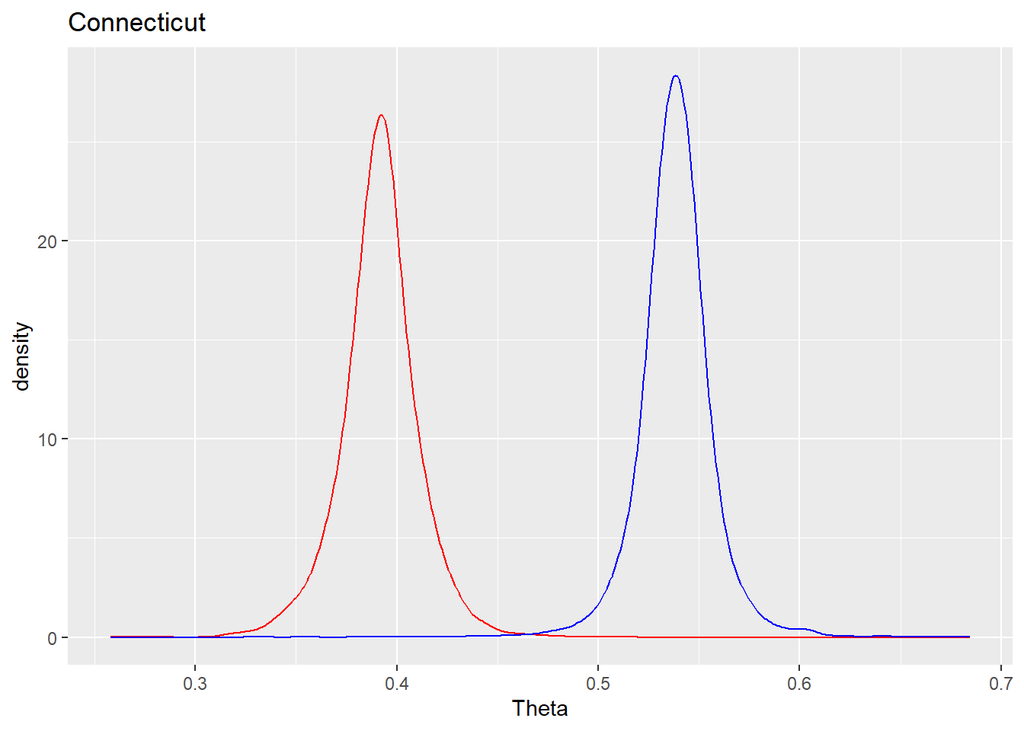

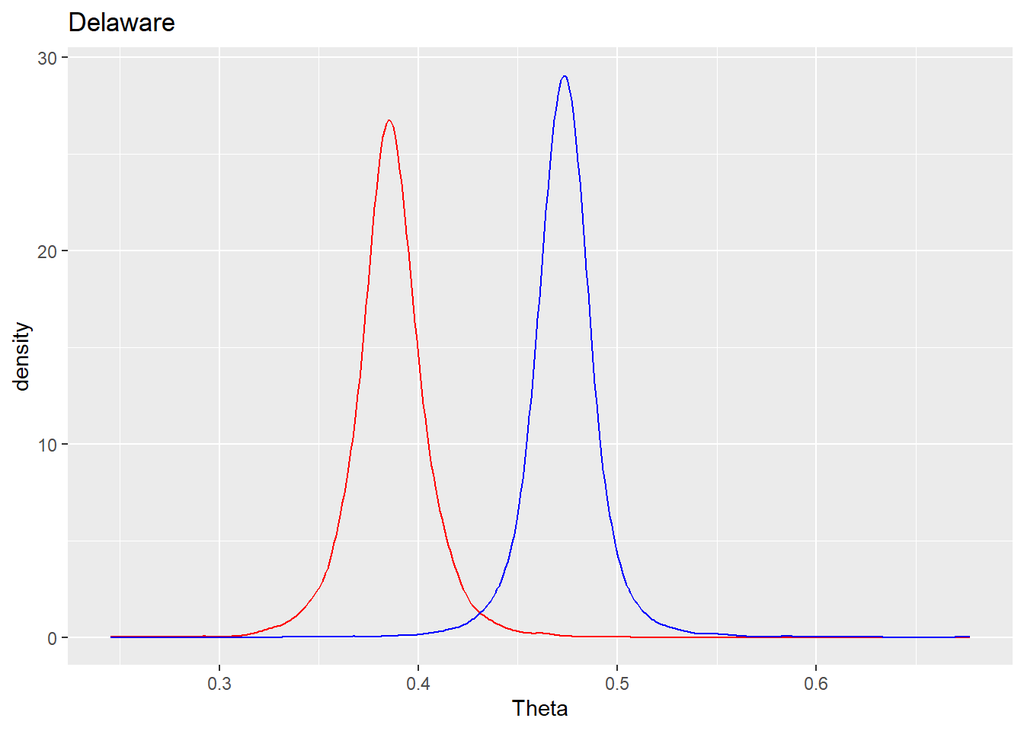

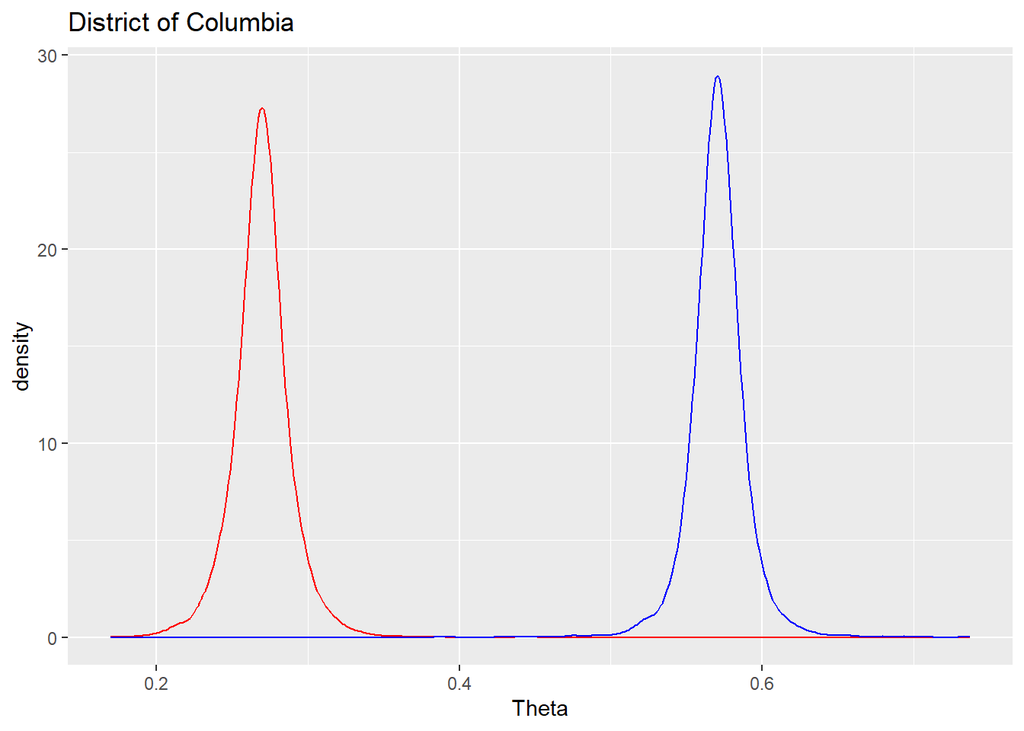

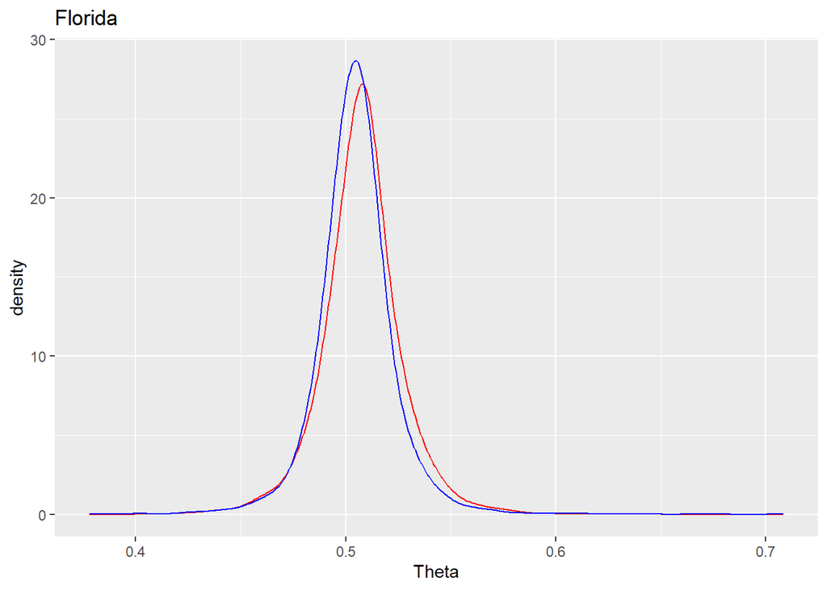

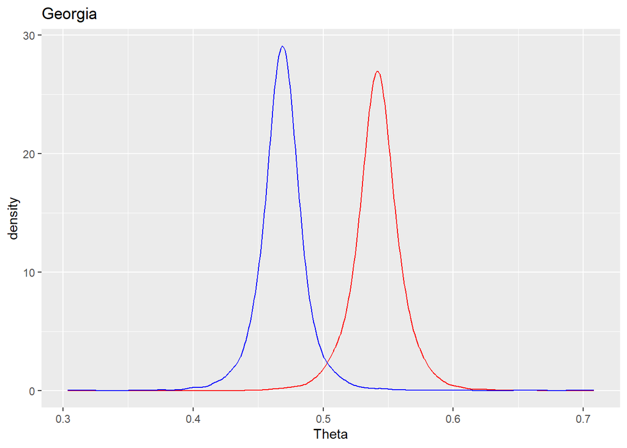

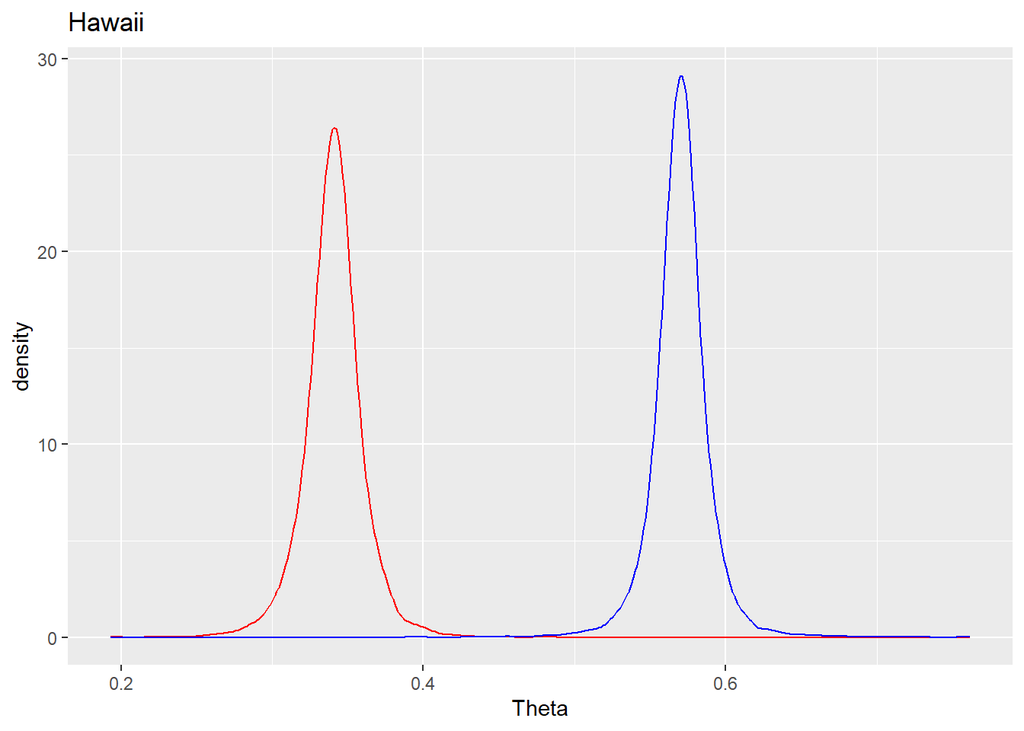

[39 more figures not shown]

```r
predict_ec <- data.frame(State = character(),
                         tp = numeric(),
                         cp = numeric())

for (state in states) {
  state_dist <- result_df[result_df$state == state, ]
  trump <- rnorm(10000, state_dist$post_mean_trump, sqrt(result_df$post_var_trump))
  clinton <- rnorm(10000, state_dist$post_mean_clinton, sqrt(result_df$post_var_clinton))

  dist_df <- data.frame(trump, clinton)

  p <- ggplot(dist_df) +
    geom_density(aes(x=trump), color = "red", adjust = 2) +
    geom_density(aes(x = clinton), color = "blue", adjust = 2) +
    labs(title = paste(state), x = "Theta")

  print(p)



  x_trump <- sample(trump, 1000, replace = TRUE)
  x_clinton <- sample(clinton, 1000, replace = TRUE)

  predict_ec <- rbind(predict_ec, data.frame(State = state, tp = x_trump, cp = x_clinton))

  ggsave(paste("density_plot_", state, ".png", sep = ""), plot = p, width = 10, height = 6)
}
```

Simulate 10,000 values for each candidate for each state and plot their posteriors. With resampling, sample 1,000 of these voter percentages for each candidate and put them in a dataframe for each state for future usage.

```r
ec <- read.csv("csvs/Electoral_College.csv")
ec <- filter(ec, Year == 2016)
ec <- ec %>% mutate(State = ifelse(State == "D.C.", "District of Columbia", State))
ec
```

```
##    Year                State Votes
## 1  2016              Alabama     9
## 2  2016               Alaska     3
## 3  2016              Arizona    11
## 4  2016             Arkansas     6
## 5  2016           California    55
## 6  2016             Colorado     9
## 7  2016          Connecticut     7
## 8  2016 District of Columbia     3
## 9  2016             Delaware     3
## 10 2016              Florida    29
## 11 2016              Georgia    16
## 12 2016               Hawaii     4
## 13 2016                Idaho     4
## 14 2016             Illinois    20
```

[output cut: 37 more lines]

```r
predict_ec$State <- as.factor(predict_ec$State)

ec_results <- predict_ec %>%
  mutate(outcome = ifelse(tp>cp, 1, 0)) %>%
  group_by(State) %>%
  summarize(Winner = ifelse((sum(outcome) > 500), "Trump", "Clinton"))

simulated_election_results <- merge(ec_results, ec, by="State") %>%
  group_by(Winner) %>%
  summarize(Electoral_College_Votes = sum(Votes))

ec_results
```

```
## # A tibble: 51 × 2
##    State                Winner
##    <fct>                <chr>
##  1 Alabama              Trump
##  2 Alaska               Trump
##  3 Arizona              Trump
##  4 Arkansas             Trump
##  5 California           Clinton
##  6 Colorado             Clinton
##  7 Connecticut          Clinton
##  8 Delaware             Clinton
##  9 District of Columbia Clinton
## 10 Florida              Trump
## # ℹ 41 more rows
```

```r
simulated_election_results
```

```
## # A tibble: 2 × 2
##   Winner  Electoral_College_Votes
##   <chr>                     <int>
## 1 Clinton                     312
## 2 Trump                       226
```

If Trump had a higher percentage for a state than Clinton, he will win that state and Vice Versa. Calculate who has more wins for each state and that candidate will win the state. This will simulate who would win the election. Here, Clinton wins with 312 votes.

```r
acc <- predict_ec %>%
  mutate(outcome = ifelse(tp>cp, 1, 0)) %>%
  group_by(State) %>%
  summarize(Trump_Win = sum(outcome),
            Clinton_Win = 1000 - Trump_Win)

acc$Winner <- c("T", "T", "T", "T", "C", "C", "C", "C", "C", "T", "T", "C", "T", "C",
                "T", "T", "T", "T", "T", "C", "C", "C", "T", "C", "T", "T", "T",
                "T", "C", "C", "C", "C", "C", "T", "T", "T", "T", "C", "T", "C", "T", "T",
                "T", "T", "T", "C", "C", "C", "T", "T", "T")

accuracy <- acc %>%
  mutate(TCorrect = ifelse(Winner == "T", Trump_Win, 0),
         CCorrect = ifelse(Winner == "C", Clinton_Win, 0)) %>%
  summarize(Total_Acc = sum(TCorrect + CCorrect) / (51000))

accuracy
```

```
## # A tibble: 1 × 1
##   Total_Acc
##       <dbl>
## 1     0.866
```

Calculating model accuracy by seeing for each state out of our 1000 simulates how many times the candidate that actually won that state won in our simulations. The model was ~86.5% accurate!